# An analysis of walkability in the United States

By: Andrew Pleat

## Intro

A popular characteristic of locations, especially cities, is walkability. Walkability is a measurement of how close by common destinations, such as stores, attractions, and workplaces. This can have important ramifications for health, the economy, and the environment. According to the [National Walkability Index](https://www.epa.gov/smartgrowth/smart-location-mapping), more walkable locations encourage less car use, more physical activity, and better access to critical services. As we continue to address the climate crisis and evaluate health systems in the United States, it is important to consider how our built environment can impact us.

The National Walkability Index is a measure created by the EPA to measure this quantitatively. This is a composite score of the intersection density (how many roads), public transit proximity, and employment/household use. For each census block group, there is a score from 1 to 20, with 1 being the worst walkability.

In this analysis, we'll look for relationships between walkability and a couple of other statistics. For example, if walkable areas encourage better health decisions, we might be able to find a correlation to health outcomes. By understanding how walkability impacts these aspects of our world at a statistical level, we can better understand how to improve on it.

### Imports

```python
import pandas as pd
import numpy as np
import matplotlib.pyplot as plt
import statsmodels.api as sm
import seaborn
import requests
```

## Data Collection

The data we're looking for is can be found at `data.gov`. We can download the data using the `requests` library. We'll save it to a file so we don't have to download it every time.

To load the data, we can simply use `pandas` to read the CSV, and we'll print out the shape of the data.

We'll also use some other datasets. The Food Access Research Atlas from the USDA measures distance to a grocery store (at different distances) and access to a car. We can use `requests` again, but the file is an Excel sheet, so we need to use a different `pandas` method to read it. We'll also need to install another dependency:

```
!pip install openpyxl
```

Finally, we'll add life expectancy. We can use a dataset from the CDC to do this.

One more thing: let's download a mapping from county name to census identifiers - we'll need this later.

```python
walkability_csv = requests.get('https://edg.epa.gov/EPADataCommons/public/OA/EPA_SmartLocationDatabase_V3_Jan_2021_Final.csv').content
with open('walkability.csv', 'wb') as f:
    f.write(walkability_csv)

food_access_csv = requests.get('https://www.ers.usda.gov/webdocs/DataFiles/80591/FoodAccessResearchAtlasData2019.xlsx?v=6872.4').content
with open('food_access.xlsx', 'wb') as f:
    f.write(food_access_csv)

life_expectancy_csv = requests.get('https://data.cdc.gov/api/views/5h56-n989/rows.csv?accessType=DOWNLOAD&bom=true&format=true').content
with open('life_expectancy.csv', 'wb') as f:
    f.write(life_expectancy_csv)
```

```python
walkability = pd.read_csv("walkability.csv", sep=',')
print(walkability.shape)

food_access = pd.read_excel("food_access.xlsx", sheet_name="Food Access Research Atlas")
print(food_access.shape)

life_expectancy = pd.read_csv("life_expectancy.csv", sep=',')
print(life_expectancy.shape)

county_mapping = pd.read_csv('https://www2.census.gov/geo/docs/reference/codes/files/national_county.txt', header=None, dtype=str, names=['STATE', 'STATEFP', 'COUNTYFP', 'COUNTYNAME', 'CLASSFP'])
```

```
(220740, 117)
(72531, 147)
(73121, 6)
```

## Data Processing

From this we see we have a *lot* of data - 117 columns and 220k data points at most. With this much data, we need to filter the data to make it more usable. Using [this legend](https://geodata.epa.gov/arcgis/rest/services/OA/WalkabilityIndex/MapServer/layers), we can remove a lot of columns. Columns like `D4C, D4D, D5CRI, etc.` are intermediate steps for the final calculations, so we can remove them. Finding a relationship between anything already measured in the walkability index won't be constructive, since we already know that relationship.

We still probably won't need most of these columns, but we can narrow it down enough for our analysis to be manageable.

We will remove rows with a state identifier over 60 - these are US territories where we don't have complete data. We also remove rows where the population is 0 - this is probably bad data, since we assume that a census area would have people in it.

These steps reduce the number of bad matches we get between our datasets.

**NOTE:** Some of these steps can break if you run them twice, since we get rid of rows in clean up that previous steps need.

```python
walkability_clean = walkability[['STATEFP', 'COUNTYFP', 'TRACTCE', 'BLKGRPCE', 'CSA', 'CSA_Name', 'CBSA', 'CBSA_Name', 'CBSA_POP', 'CBSA_EMP',
             'CBSA_WRK', 'Ac_Total', 'TotPop', 'CountHU', 'HH', 'P_WrkAge', 'AutoOwn0', 'Pct_AO0', 'AutoOwn1', 'Pct_AO1',
             'AutoOwn2p', 'Pct_AO2p', 'Workers', 'R_LowWageWk', 'R_MedWageWk', 'R_HiWageWk', 'R_PCTLOWWAGE', 'TotEmp',
             'E_LowWageWk', 'E_MedWageWk', 'E_HiWageWk', 'E_PctLowWage', 'D2A_Ranked', 'D2B_Ranked', 'D3B_Ranked', 'D4A_Ranked',
             'NatWalkInd', 'Shape_Length', 'Shape_Area']]

walkability_clean = walkability_clean[walkability_clean['STATEFP'] < 60]
walkability_clean = walkability_clean[walkability_clean['TotPop'] != 0]
```

```python
food_access_clean = food_access[['CensusTract', 'State', 'County', 'Urban', 'OHU2010', 'LILATracts_1And10', 'LILATracts_halfAnd10', 'LILATracts_1And20',
                                 'LILATracts_Vehicle', 'HUNVFlag', 'LowIncomeTracts', 'PovertyRate', 'MedianFamilyIncome', 'LA1and10', 'LAhalfand10',
                                 'LA1and20', 'LATracts_half', 'LATracts1', 'LATracts10', 'LATracts20', 'LATractsVehicle_20', 'lapophalfshare',
                                 'lalowihalfshare', 'lahunvhalfshare', 'lasnaphalfshare', 'lapop1share', 'lalowi1share', 'lahunv1share',
                                 'lasnap1share', 'lapop10share', 'lalowi10share', 'lahunv10share', 'lasnap10share', 'lapop20share',
                                 'lalowi20share', 'lahunv20share', 'lasnap20share', 'TractLOWI', 'TractHUNV']]
```

```python
life_expectancy_clean = life_expectancy[['State', 'County', 'Census Tract Number', 'Life Expectancy']]
life_expectancy_clean['LifeExpectancy'] = life_expectancy_clean['Life Expectancy']  # space in column will break things
life_expectancy_clean = life_expectancy_clean.drop(columns=['Life Expectancy'])
```

We now need to combine these tables together so that we can do analysis on them. We'll try to add all of our data onto the walkability index.

First, lets add the life expectancy table. First, we split the county as it contains both county and state name. Some rows don't have a census tract, which are summary rows for counties or states, and we remove them.

We then merge this with our county mapping table downloaded earlier, associating each county and state name with a FIPS identifier. Some rows don't get matched, which results from bad data, so we remove them.

We strip leading 0's from the county and state, and convert the tract number by formatting it with 2 decimal digits, then removing the decimal point. Now, we can join the two tables together.

We see that we only have 118 rows that can't be matched. To fix these, we would need to understand more about each individual area, and some other columns are missing, so its safe to assume that this isn't perfect data and we can ignore it. This essentially calculates an inner join rather than a left join, but its nice to know how many rows we couldn't match.

```python
life_expectancy_clean[['CountyPart', 'StatePart']] = life_expectancy_clean['County'].str.split(', ', expand=True)
life_expectancy_clean = life_expectancy_clean[life_expectancy_clean['Census Tract Number'].notna()]
life_expectancy_clean = life_expectancy_clean.merge(county_mapping, left_on=['StatePart', 'CountyPart'], right_on=['STATE', 'COUNTYNAME'], how='left')
life_expectancy_clean = life_expectancy_clean[life_expectancy_clean['COUNTYFP'].notna()]
life_expectancy_clean = life_expectancy_clean[['STATE', 'COUNTYNAME', 'COUNTYFP', 'STATEFP', 'Census Tract Number', 'LifeExpectancy']]

life_expectancy_clean['COUNTYFP'] = life_expectancy_clean['COUNTYFP'].str.lstrip('0').astype(int)
life_expectancy_clean['STATEFP'] = life_expectancy_clean['STATEFP'].str.lstrip('0').astype(int)
life_expectancy_clean['TRACTCE'] = life_expectancy_clean['Census Tract Number'].astype(float).apply(lambda x: "{:.2f}".format(x).replace('.', '')).astype(int)
life_expectancy_clean = life_expectancy_clean.drop(columns=['Census Tract Number'], axis=1)

merged = walkability_clean.merge(life_expectancy_clean, on=['STATEFP', 'COUNTYFP', 'TRACTCE'], how='left')
print(merged[merged['COUNTYNAME'].isna()].shape)
merged = merged[merged['COUNTYNAME'].notna()]
```

```
(118, 42)
```

The food access dataset is a bit easier to deal with. We have a `CensusTract` field, which we can split as we need. We take the first 2 digits as the state, the next 3 digits as the county, and the remaining digits as the tract. When we merge, we only get 13 bad results, which is good enough that we'll ignore those as well.

```python
food_access_clean['STATEFP'] = food_access_clean['CensusTract'] // 1e9
food_access_clean['COUNTYFP'] = (food_access_clean['CensusTract'] // 1e6) % 1e3
food_access_clean['TRACTCE'] = food_access_clean['CensusTract'] % 1e6
food_access_clean = food_access_clean.drop(columns=['State', 'County'], axis=1)

merged = merged.merge(food_access_clean, on=['STATEFP', 'COUNTYFP', 'TRACTCE'], how='left')
print(merged[merged['LA1and10'].isna()].shape)
merged = merged[merged['LA1and10'].notna()]
```

```
(13, 79)
```

## Data Analysis/Visualization

A simple first visualization is the population split by walkability score. We can use a pie chart to show this. First, we round the walkability index to the nearest 2, then we group them together and sum the total population in each group.

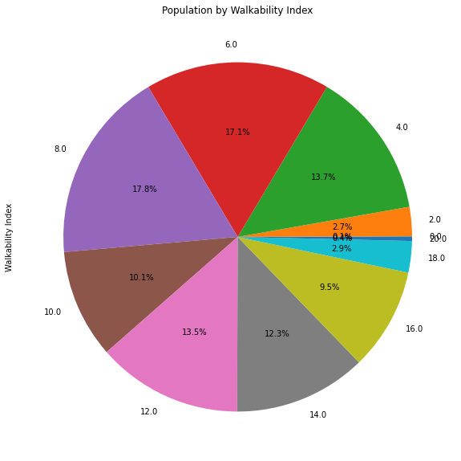

```python
rounding = merged.copy()
rounding['NatWalkInd'] = np.round(rounding['NatWalkInd']/2)*2
rounding.groupby('NatWalkInd')['TotPop'].sum().plot(kind='pie', figsize=(10,10), autopct='%1.1f%%', fontsize=10, ylabel='Walkability Index', title='Population by Walkability Index')
plt.show()
```

To find correlations between data points, let's first just plot one of our columns against walkability index, starting with life expectancy.

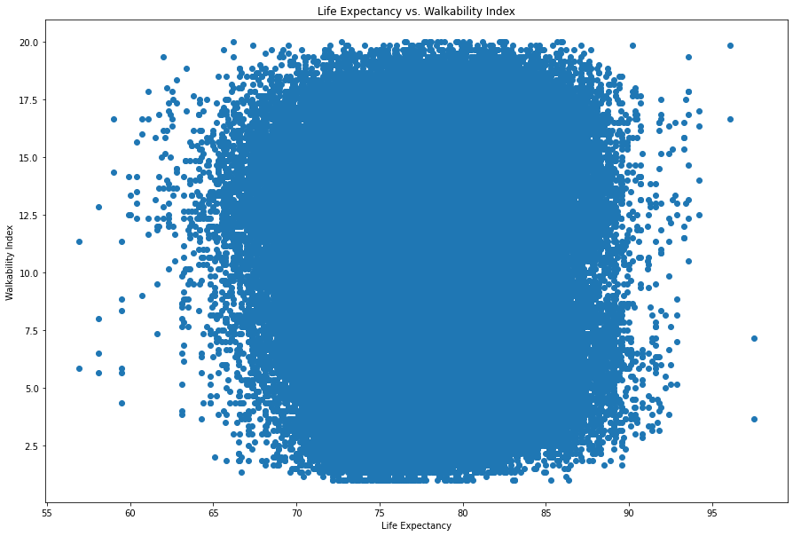

```python
plt.figure(figsize=(15, 10))
plt.scatter(merged['LifeExpectancy'], merged['NatWalkInd'])
plt.xlabel('Life Expectancy')
plt.ylabel('Walkability Index')
plt.title('Life Expectancy vs. Walkability Index')

plt.show()
```

From this, we can't see anything because of how many points there are. We can randomly sample the data to try and get a better visualization.

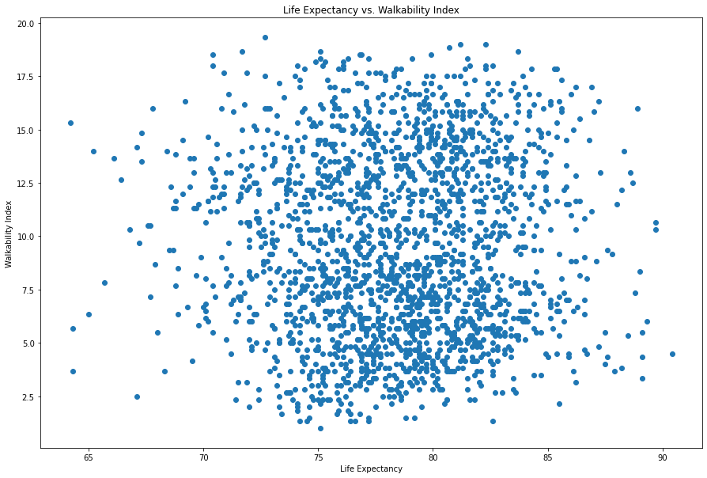

```python
subset01 = merged.sample(frac=0.01)
plt.figure(figsize=(15, 10))
plt.scatter(subset01['LifeExpectancy'], subset01['NatWalkInd'])
plt.xlabel('Life Expectancy')
plt.ylabel('Walkability Index')
plt.title('Life Expectancy vs. Walkability Index')

plt.show()
```

It doesn't look like there's much of a correlation here. We'll check this with real models later. From now on, we'll use this reduced dataset in our plots to be able to better visualize what's happening.

Another way to visualize this statistic is to use a violin plot and group the walkability scores into buckets. I chose to use this type of plot so that we can better visualize the data in segments - each part of the plot shows a single bucket and the minimum, maximum, median, and distribution of the data within that bucket. We'll also add the number of observations in each bucket so we can determine which buckets have enough data to be significant.

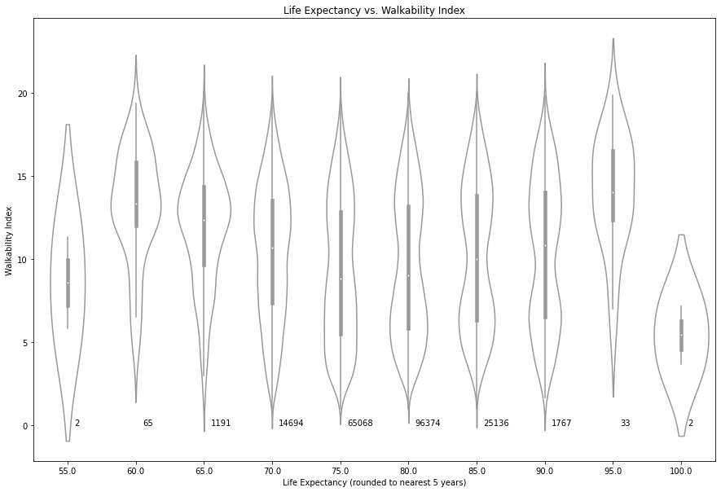

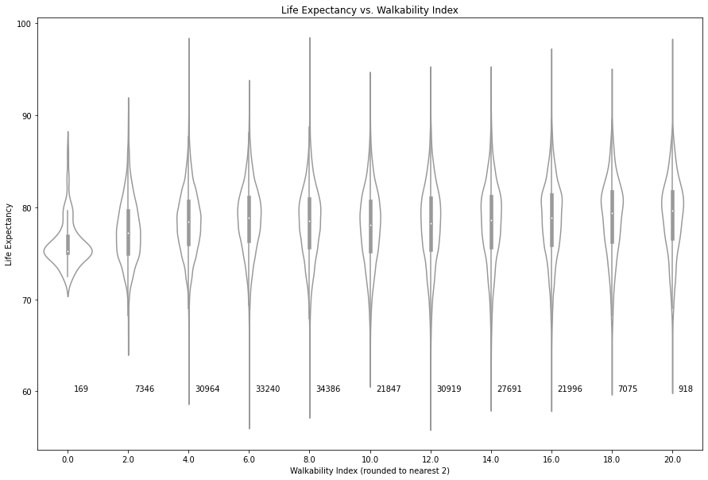

```python
bucketing = merged.copy()
bucketing['rounded_walk'] = np.round(bucketing['NatWalkInd']/2)*2
bucketing['rounded_exp'] = round(bucketing['LifeExpectancy']/5)*5

plt.figure(figsize=(15, 10))
vio = seaborn.violinplot(x='rounded_exp', y='NatWalkInd', data=bucketing, color='white')

counts = bucketing['rounded_exp'].value_counts().sort_index().values
for i in range(len(counts)):
   vio.text(i+0.1, 0, counts[i])
plt.xlabel('Life Expectancy (rounded to nearest 5 years)')
plt.ylabel('Walkability Index')
plt.title('Life Expectancy vs. Walkability Index')
plt.show()

plt.figure(figsize=(15, 10))
vio = seaborn.violinplot(x='rounded_walk', y='LifeExpectancy', data=bucketing, color='white')
counts = bucketing['rounded_walk'].value_counts().sort_index().values

for i in range(len(counts)):
   vio.text(i+0.1, 60, counts[i])
plt.xlabel('Walkability Index (rounded to nearest 2)')
plt.ylabel('Life Expectancy')
plt.title('Life Expectancy vs. Walkability Index')
plt.show()
```

Lets try the same idea with poverty rate.

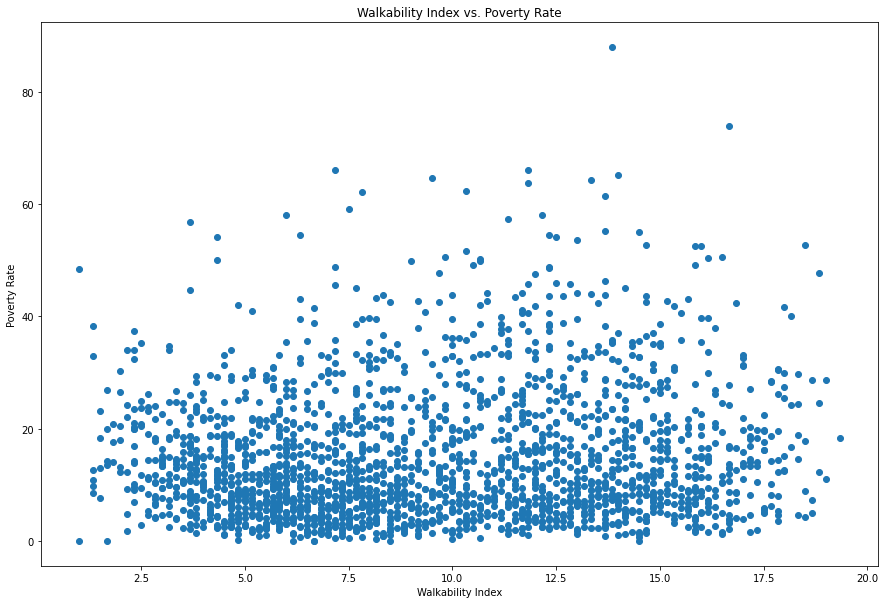

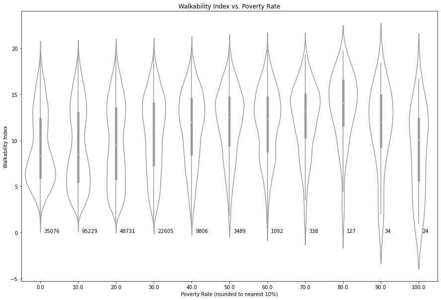

```python
plt.figure(figsize=(15, 10))
plt.scatter(subset01['NatWalkInd'], subset01['PovertyRate'])
plt.xlabel('Walkability Index')
plt.ylabel('Poverty Rate')
plt.title('Walkability Index vs. Poverty Rate')
plt.show()

bucketing['rounded_pov'] = round(bucketing['PovertyRate']/10)*10

plt.figure(figsize=(15, 10))
vio = seaborn.violinplot(x='rounded_pov', y='NatWalkInd', data=bucketing, color='white')

counts = bucketing['rounded_pov'].value_counts().sort_index().values

for i in range(len(counts)):
   vio.text(i+0.1, 0, counts[i])
plt.xlabel('Poverty Rate (rounded to nearest 10%)')
plt.ylabel('Walkability Index')
plt.title('Walkability Index vs. Poverty Rate')
plt.show()
```

We can definitely see a trend upward in walkability index as poverty rate increases.

We'll repeat with the percentage of the population more than 1/2 mile from a supermarket.

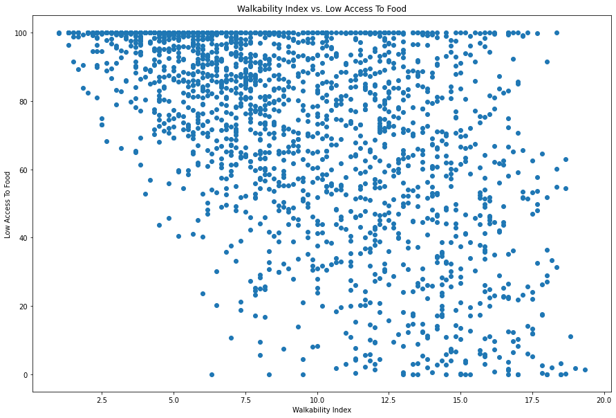

```python
plt.figure(figsize=(15, 10))
plt.scatter(subset01['NatWalkInd'], subset01['lapophalfshare'])
plt.xlabel('Walkability Index')
plt.ylabel('Low Access To Food')
plt.title('Walkability Index vs. Low Access To Food')
plt.show()
```

Here we can definitely see a correlation, but this makes sense - the more walkable a location is, the more likely the population has access to food. While access to food is not *directly* measured by the walkability index, its closely enough related in nature that there isn't much insight gained here.

The last measurement we'll look at is access to a car.

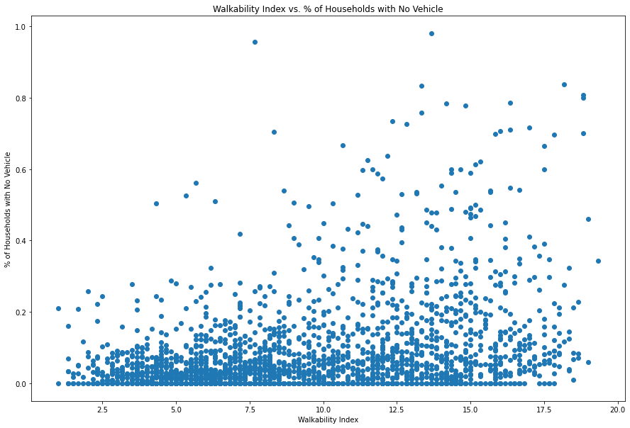

```python
plt.figure(figsize=(15, 10))

plt.scatter(subset01['NatWalkInd'], subset01['Pct_AO0'])
plt.xlabel('Walkability Index')
plt.ylabel('% of Households with No Vehicle')
plt.title('Walkability Index vs. % of Households with No Vehicle')
```

We can see that the areas with less access to a vehicle generally are more walkable. We also should investigate whether this has an effect on poverty rate.

## Hypothesis Testing

We now have a couple of angles of analysis that we can investigate further. First, we'll look at the relationship between walkability and life expectancy. Earlier the violin plot showed that there appears to be a quadratic relationship between the two. Let's use the `statsmodels` library to create a model analyzing this trend to see if there is a significant relationship.

Since we have so much data, we should run the regression model on our subset dataset - with the amount of data we have, almost every relationship will be significant unless we sample it first.

First, we add a new column for life expectancy squared as to create a quadratic model. We then run the model and output the results. We can also plot this curve on a scatterplot of the data by using the outputed parameters.

```
                            OLS Regression Results
==============================================================================
Dep. Variable:             NatWalkInd   R-squared:                       0.013
Model:                            OLS   Adj. R-squared:                  0.012
Method:                 Least Squares   F-statistic:                     13.51
Date:                Fri, 12 May 2023   Prob (F-statistic):           1.48e-06
Time:                        18:21:30   Log-Likelihood:                -5894.7
No. Observations:                2032   AIC:                         1.180e+04
Df Residuals:                    2029   BIC:                         1.181e+04
Df Model:                           2
Covariance Type:            nonrobust
==================================================================================
                     coef    std err          t      P>|t|      [0.025      0.975]
----------------------------------------------------------------------------------
Intercept        134.1164     24.403      5.496      0.000      86.259     181.974
LifeExpectancy    -3.2316      0.629     -5.136      0.000      -4.466      -1.998
exp_squared        0.0209      0.004      5.163      0.000       0.013       0.029
==============================================================================
Omnibus:                      752.493   Durbin-Watson:                   1.991
Prob(Omnibus):                  0.000   Jarque-Bera (JB):              107.363
Skew:                           0.142   Prob(JB):                     4.86e-24
Kurtosis:                       1.910   Cond. No.                     1.54e+06
==============================================================================

Notes:
[1] Standard Errors assume that the covariance matrix of the errors is correctly specified.
[2] The condition number is large, 1.54e+06. This might indicate that there are
strong multicollinearity or other numerical problems.
```

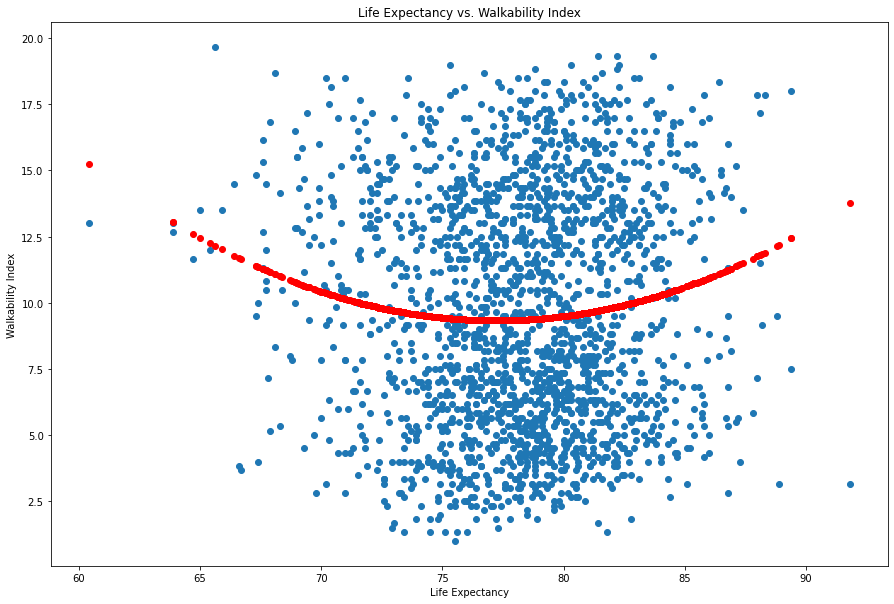

```python
merged['exp_squared'] = merged['LifeExpectancy'] ** 2
subset01 = merged.sample(frac=0.01)
model = sm.formula.ols(formula="NatWalkInd ~ LifeExpectancy + exp_squared", data=subset01).fit()
print(model.summary())


plt.figure(figsize=(15, 10))
plt.scatter(subset01['LifeExpectancy'], subset01['NatWalkInd'])
plt.xlabel('Life Expectancy')
plt.ylabel('Walkability Index')
plt.title('Life Expectancy vs. Walkability Index')
plt.scatter(subset01['LifeExpectancy'], model.predict(subset01), color='red')
plt.show()
```

We can see from the model output that all of the p-values of the coefficents are <.05, so this is technically a statistically significant result. However, we can see that the confidence intervals for the coefficients are very large and the R-squared value is very low, so this model is not very good. We can also see from the graph that the model is not a good fit for the data.

Lets try adding poverty rate as an interaction term. We identified a minor relationship between poverty rate and walkability earlier, so this might help the model.

```python
model = sm.formula.ols(formula="NatWalkInd ~ (LifeExpectancy + exp_squared) + PovertyRate", data=subset01).fit()
print(model.summary())
```

```
                            OLS Regression Results
==============================================================================
Dep. Variable:             NatWalkInd   R-squared:                       0.035
Model:                            OLS   Adj. R-squared:                  0.034
Method:                 Least Squares   F-statistic:                     24.60
Date:                Fri, 12 May 2023   Prob (F-statistic):           1.24e-15
Time:                        18:21:30   Log-Likelihood:                -5871.9
No. Observations:                2032   AIC:                         1.175e+04
Df Residuals:                    2028   BIC:                         1.177e+04
Df Model:                           3
Covariance Type:            nonrobust
==================================================================================
                     coef    std err          t      P>|t|      [0.025      0.975]
----------------------------------------------------------------------------------
Intercept         94.4273     24.833      3.803      0.000      45.727     143.127
LifeExpectancy    -2.3530      0.636     -3.702      0.000      -3.600      -1.106
exp_squared        0.0160      0.004      3.930      0.000       0.008       0.024
PovertyRate        0.0746      0.011      6.795      0.000       0.053       0.096
==============================================================================
Omnibus:                      505.041   Durbin-Watson:                   1.978
Prob(Omnibus):                  0.000   Jarque-Bera (JB):               93.910
Skew:                           0.132   Prob(JB):                     4.05e-21
Kurtosis:                       1.981   Cond. No.                     1.59e+06
==============================================================================

Notes:
[1] Standard Errors assume that the covariance matrix of the errors is correctly specified.
[2] The condition number is large, 1.59e+06. This might indicate that there are
strong multicollinearity or other numerical problems.
```

```
                            OLS Regression Results
==============================================================================
Dep. Variable:            PovertyRate   R-squared:                       0.021
Model:                            OLS   Adj. R-squared:                  0.020
Method:                 Least Squares   F-statistic:                     45.62
Date:                Fri, 12 May 2023   Prob (F-statistic):           1.84e-11
Time:                        18:21:30   Log-Likelihood:                -8375.1
No. Observations:                2166   AIC:                         1.675e+04
Df Residuals:                    2164   BIC:                         1.677e+04
Df Model:                           1
Covariance Type:            nonrobust
==============================================================================
                 coef    std err          t      P>|t|      [0.025      0.975]
------------------------------------------------------------------------------
Intercept     11.6070      0.597     19.445      0.000      10.436      12.778
NatWalkInd     0.3765      0.056      6.754      0.000       0.267       0.486
==============================================================================
Omnibus:                      682.575   Durbin-Watson:                   1.969
Prob(Omnibus):                  0.000   Jarque-Bera (JB):             2317.992
Skew:                           1.559   Prob(JB):                         0.00
Kurtosis:                       6.996   Cond. No.                         25.9
==============================================================================

Notes:
[1] Standard Errors assume that the covariance matrix of the errors is correctly specified.
```

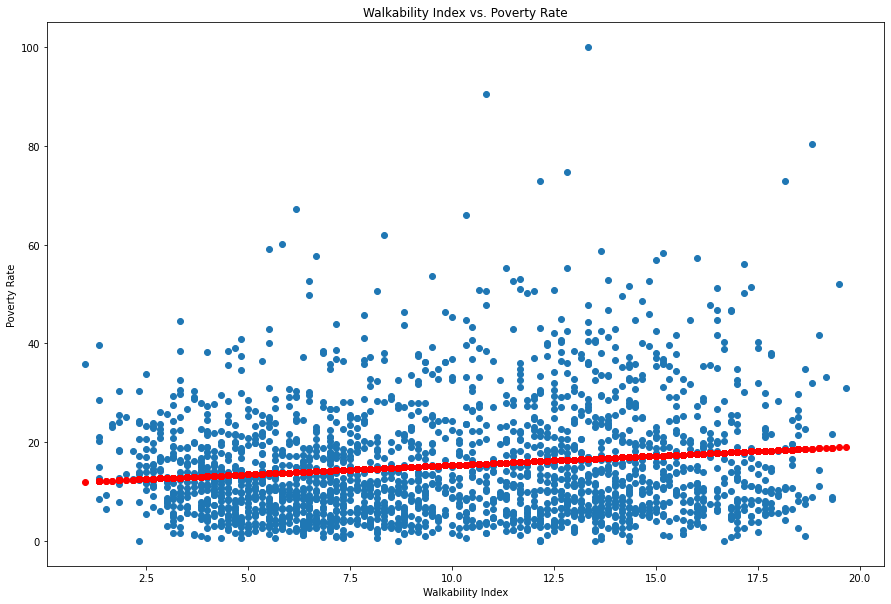

```python
model = sm.formula.ols(formula="PovertyRate ~ NatWalkInd", data=subset01).fit()
print(model.summary())

plt.figure(figsize=(15, 10))
plt.scatter(subset01['NatWalkInd'], subset01['PovertyRate'])
plt.xlabel('Walkability Index')
plt.ylabel('Poverty Rate')
plt.title('Walkability Index vs. Poverty Rate')
plt.scatter(subset01['NatWalkInd'], model.predict(subset01), color='red')
plt.show()
```

Once again, we find a statistically significant relationship, but the model doesn't do a great job of explaining the variance in the data. From a practical perspective, many areas that are more walkable are more dense (in cities) where the poverty rate might be higher. Adding density as an interaction term might help the model. We can calculate the population density by dividing the population by the area.

```python
merged['density'] = merged['TotPop'] / merged['Ac_Total']
merged['density_std'] = (merged['density'] - merged['density'].mean()) / merged['density'].std()
subset01 = merged.sample(frac=0.01)

model = sm.formula.ols(formula="PovertyRate ~ NatWalkInd * density", data=subset01).fit()
print(model.summary())
```

```
                            OLS Regression Results
==============================================================================
Dep. Variable:            PovertyRate   R-squared:                       0.026
Model:                            OLS   Adj. R-squared:                  0.025
Method:                 Least Squares   F-statistic:                     19.32
Date:                Fri, 12 May 2023   Prob (F-statistic):           2.32e-12
Time:                        18:21:30   Log-Likelihood:                -8288.1
No. Observations:                2166   AIC:                         1.658e+04
Df Residuals:                    2162   BIC:                         1.661e+04
Df Model:                           3
Covariance Type:            nonrobust
======================================================================================
                         coef    std err          t      P>|t|      [0.025      0.975]
--------------------------------------------------------------------------------------
Intercept             12.5657      0.593     21.190      0.000      11.403      13.729
NatWalkInd             0.1967      0.058      3.366      0.001       0.082       0.311
density                0.1150      0.038      3.051      0.002       0.041       0.189
NatWalkInd:density    -0.0046      0.003     -1.673      0.094      -0.010       0.001
==============================================================================
Omnibus:                      615.894   Durbin-Watson:                   1.944
Prob(Omnibus):                  0.000   Jarque-Bera (JB):             1804.323
Skew:                           1.459   Prob(JB):                         0.00
Kurtosis:                       6.388   Cond. No.                         954.
==============================================================================

Notes:
[1] Standard Errors assume that the covariance matrix of the errors is correctly specified.
```

Unfortunately, we find that density as an interaction term is not significant, and density on its own isn't a great predictor of poverty rate. Below we'll just plot density vs walkability.

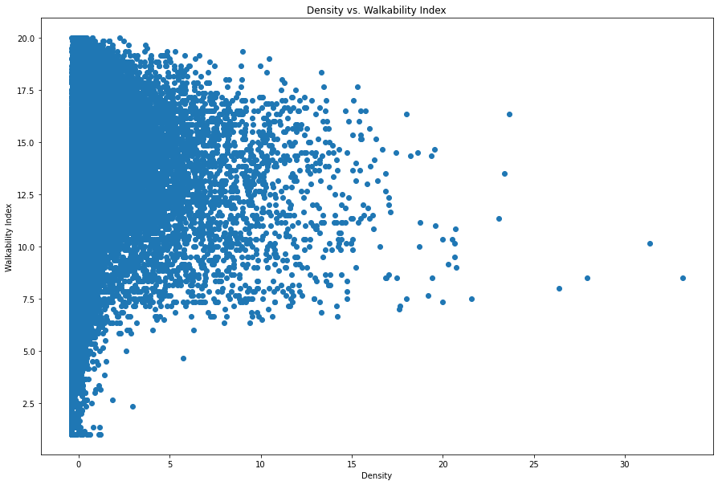

```
148774    New York-Newark-Jersey City, NY-NJ-PA
149415    New York-Newark-Jersey City, NY-NJ-PA
150634    New York-Newark-Jersey City, NY-NJ-PA
150637    New York-Newark-Jersey City, NY-NJ-PA
153122    New York-Newark-Jersey City, NY-NJ-PA
155145    New York-Newark-Jersey City, NY-NJ-PA
155600    New York-Newark-Jersey City, NY-NJ-PA
Name: CBSA_Name, dtype: object
```

```python
plt.figure(figsize=(15, 10))
plt.scatter(merged['density_std'], merged['NatWalkInd'])
plt.xlabel('Density')
plt.ylabel('Walkability Index')
plt.title('Density vs. Walkability Index')
plt.show()
display(merged[merged['density_std'] >22]['CBSA_Name'])
```

There are a couple of insights we can see here. This graph confirms the common idea that more dense areas are more walkable by nature. Yet surprisingly, the most dense cities/areas are not at the top of the walkability scale. The most walkable areas have a low-medium density.

The final analysis we'll look at is how walkability and vehicle availability are related, and how they affect poverty rate when combined. First, we will sample the data that is marked as a low income area according to the food access database. We can then plot the relationship between walkability and vehicle availability, separated out by income level.

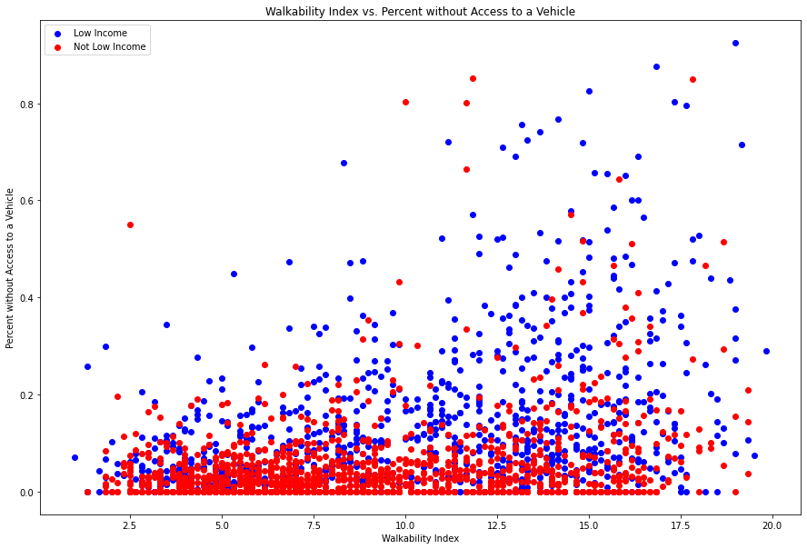

```python
subsetLowIncome = merged[merged['LowIncomeTracts'] == 1].sample(frac=0.01)
subsetNotLowIncome = merged[merged['LowIncomeTracts'] == 0].sample(frac=0.01)
plt.figure(figsize=(15, 10))

plt.scatter(subsetLowIncome['NatWalkInd'], subsetLowIncome['Pct_AO0'], color='blue', label='Low Income')
plt.scatter(subsetNotLowIncome['NatWalkInd'], subsetNotLowIncome['Pct_AO0'], color='red' , label='Not Low Income')
plt.xlabel('Walkability Index')
plt.ylabel('Percent without Access to a Vehicle')
plt.title('Walkability Index vs. Percent without Access to a Vehicle')
plt.legend()
plt.show()
```

As you might expect, areas not considered low income have nearly everyone having access to a car. However, above about 20% of the population having no access to a vehicle, we see some trends emerge. In areas with very low car access, these are mostly low income areas. Additionally, mroe walkable areas have a higher variance in vehicle access - you would expect non-walkable areas to require a vehicle.

Next, we will examine the data with 'low' vehicle access. The food access dataset defines this as >100 households not having access to a car, but this doesn't account for the population size in each area, so I instead defined it as 20% or greater of the population not having access to a car. We can then plot the relationship between walkability and poverty rate, separated out by vehicle access.

Let's print out the poverty rate statistics for these low vehicle access areas, split by walkability.

```python
low_vehicle = merged[merged['Pct_AO0'] > 0.20]
print(low_vehicle[low_vehicle['NatWalkInd'] > 10]['PovertyRate'].describe())
print(low_vehicle[low_vehicle['NatWalkInd'] < 10]['PovertyRate'].describe())
```

```
count    22449.000000
mean        26.421146
std         14.479527
min          0.000000
25%         15.110827
50%         24.948176
75%         35.858916
max        100.000000
Name: PovertyRate, dtype: float64
count    5581.000000
mean       26.940497
std        14.200520
min         0.000000
25%        15.975998
50%        25.872841
75%        36.303940
max       100.000000
Name: PovertyRate, dtype: float64
```

We also will sample the low vehicle access data at a higher rate, since we've eliminated most of the data.

```
                            OLS Regression Results
==============================================================================
Dep. Variable:            PovertyRate   R-squared:                       0.003
Model:                            OLS   Adj. R-squared:                  0.002
Method:                 Least Squares   F-statistic:                     7.849
Date:                Fri, 12 May 2023   Prob (F-statistic):            0.00512
Time:                        18:21:31   Log-Likelihood:                -11570.
No. Observations:                2829   AIC:                         2.314e+04
Df Residuals:                    2827   BIC:                         2.316e+04
Df Model:                           1
Covariance Type:            nonrobust
==============================================================================
                 coef    std err          t      P>|t|      [0.025      0.975]
------------------------------------------------------------------------------
Intercept     28.9897      1.005     28.841      0.000      27.019      30.961
NatWalkInd    -0.2116      0.076     -2.802      0.005      -0.360      -0.063
==============================================================================
Omnibus:                      200.365   Durbin-Watson:                   2.034
Prob(Omnibus):                  0.000   Jarque-Bera (JB):              244.381
Skew:                           0.683   Prob(JB):                     8.58e-54
Kurtosis:                       3.453   Cond. No.                         49.5
==============================================================================

Notes:
[1] Standard Errors assume that the covariance matrix of the errors is correctly specified.
```

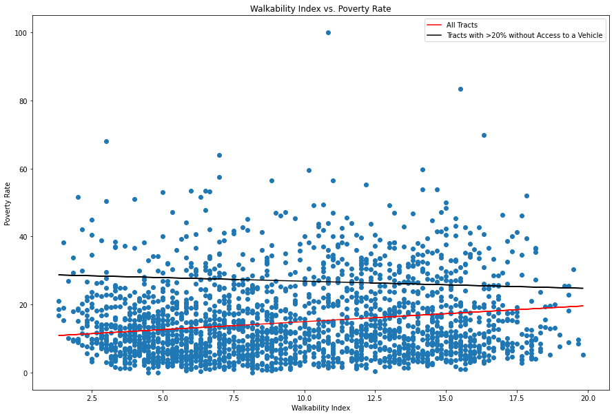

```python
model = sm.formula.ols(formula="PovertyRate ~ NatWalkInd", data=merged.sample(frac=0.01)).fit()
model_vehicle = sm.formula.ols(formula="PovertyRate ~ NatWalkInd", data=low_vehicle.sample(frac=0.1)).fit()
print(model_vehicle.summary())
plt.figure(figsize=(15, 10))
plt.scatter(subset01['NatWalkInd'], subset01['PovertyRate'])
plt.plot(subset01['NatWalkInd'], model.predict(subset01[['NatWalkInd']]), color='red', label='All Tracts')
plt.plot(subset01['NatWalkInd'], model_vehicle.predict(subset01[['NatWalkInd']]), color='black', label='Tracts with >20% without Access to a Vehicle')
plt.xlabel('Walkability Index')
plt.ylabel('Poverty Rate')
plt.title('Walkability Index vs. Poverty Rate')
plt.legend()
plt.show()
```

The result of the model is statistically significant, but we don't see a strong correlation. In general, as walkability increases, the poverty rate increases. For regions with low car access, as walkability increases, poverty rate slightly decreases.

## Insights

Unfortunately, most of the hypotheses we tested did not have a clearly defined relationship. At the beginning, we assumed that walkability would have an impact on health outcomes such as life expectancy, or social outcomes such as poverty rate. We did find that as walkability increases, the poverty rate increases, however the model was not very strong, indicating that there are other factors involved. When dealing with a large amount of data and a wide range of real-world scenarios, it is difficult to find a strong correlation between any two variables. However, I was surprised to find that including density did not noticeably improve the model, as walkability and density are often linked closely.

The last point of analysis we looked at was vehicle access and walkability. For low car access areas, walkability and poverty rate are inversely correlated somewhat. It is possible this is because being able to live in a very walkable area requires a higher income level. Additionally, this could indicate that people who live in a low walkability area and have no access to a car are more likely to be in poverty because they have less access to resources.

To get a better understanding of walkability and how it impacts people, we need to first understand systemic issues such as poverty and how it relates to other factors such as education and historical discrimiatory practices. Residential/commercial mix, a factor in the walkability score, has historically been linked to redlining and racial discrimination - creating a model of walkability would be incomplete without considering how this effects populations. Further research into these areas is important to determine how we can improve on factors such as life expectancy and get a more complete understanding of how walkability impacts people.

#### Additional Resources

- [Walkability: what is it?](https://edisciplinas.usp.br/pluginfile.php/5068341/mod_resource/content/0/LO%202009%20-%20Walkability%20what%20is%20it.pdf)
- [Walkability and Its Relationships With Health, Sustainability, and Livability](https://www.frontiersin.org/articles/10.3389/fbuil.2021.721218/full)
- [What Walkability Means for the D.C. Area](https://gwtoday.gwu.edu/q-what-walkability-means-dc-area)
- [Design for Walkability](http://www.designforwalkability.com/)